# Analisis Klaster K-Prototype & Partitioning Around Medoids (PAM) dengan Gower Distance

Sahat Renaldi. S

10-06-2024

```r
## Clustering
library(cluster)
library(factoextra)
library(FactoMineR)


## Clustering Visualization
library(Rtsne)
library(rgl)
library(plotly)
library(ggplot2)

# Knit
library(knitr)
library(rgl)

# Data Preprocessing
library(dplyr)
library(tibble)
```

# 1 Data Preparation

```r
library(dplyr)

df <- read.csv("data_hasil_ekstrak_maps.csv",
               stringsAsFactors = T, header=TRUE, sep=",", row.names=NULL)

glimpse(df)
```

```
#> Rows: 677
#> Columns: 19
#> $ X             <int> 0, 1, 2, 3, 4, 5, 6, 7, 8, 9, 10, 11, 12, 13, 14, 15, 16…
#> $ Link          <fct> https://mamikos.com/room/kost-kota-surabaya-kost-putri-m…
#> $ Nama          <fct> Kost Singgahsini Rungkut Asri Utara XI Tipe C Rungkut Su…
#> $ Lokasi        <fct> Rungkut, Rungkut, Rungkut, Rungkut, Rungkut, Rungkut, Ru…
#> $ Harga         <int> 880000, 1275000, 925000, 2525000, 2025000, 2325000, 1350…
#> $ Jenis         <fct> Putri, Putri, Putri, Putri, Putri, Putri, Putra, Campur,…
#> $ Listrik       <fct> Tidak termasuk listrik, Tidak termasuk listrik, Tidak te…
#> $ Luas.Kamar    <dbl> 5, 5, 6, 20, 16, 20, 9, 12, 9, 9, 20, 9, 24, 16, 9, 15, …
#> $ K.Mandi.Dalam <fct> No, No, No, Yes, Yes, Yes, Yes, Yes, No, Yes, Yes, Yes, …
#> $ AC            <fct> No, Yes, No, Yes, Yes, Yes, Yes, Yes, Yes, No, Yes, Yes,…
#> $ WiFi          <fct> Yes, Yes, Yes, Yes, Yes, Yes, Yes, Yes, Yes, Yes, Yes, Y…
#> $ Kasur         <fct> Yes, Yes, Yes, Yes, Yes, Yes, Yes, Yes, Yes, Yes, Yes, Y…
#> $ Akses.24.Jam  <fct> Yes, Yes, Yes, Yes, Yes, Yes, No, Yes, Yes, Yes, Yes, No…
#> $ Panjang.Kamar <dbl> 2, 2, 2, 5, 4, 4, 3, 3, 3, 3, 4, 3, 3, 4, 3, 3, 3, 3, 3,…
#> $ Lebar.Kamar   <dbl> 2.5, 2.5, 3.0, 4.0, 4.0, 5.0, 3.0, 4.0, 3.0, 3.0, 5.0, 3…
#> $ Maps          <fct> "https://maps.google.com/maps?z=7&q=-7.3232453,112.77409…
#> $ Latitude      <dbl> -7.323245, -7.323245, -7.323245, -7.319905, -7.319905, -…
#> $ Longitude     <dbl> 112.7741, 112.7741, 112.7741, 112.7977, 112.7977, 112.79…
#> $ UPN           <dbl> 1.9221064, 1.9221064, 1.9221064, 1.7472292, 1.7472292, 1…
```

# 2 Exploratory Data Analysis

## 2.1 Eksplorasi Data Numerik

```r
summary(df$Harga)
```

```
#>    Min. 1st Qu.  Median    Mean 3rd Qu.    Max.
#>  350000  800000 1200000 1283238 1600000 8250000
```

```r
summary(df$Luas.Kamar)
```

```
#>    Min. 1st Qu.  Median    Mean 3rd Qu.    Max.
#>    4.00    9.00   12.00   11.79   12.00  120.00
```

```r
summary(df$UPN)
```

```
#>    Min. 1st Qu.  Median    Mean 3rd Qu.    Max.
#>  0.2662  4.1047  6.1850  5.7856  7.5069 14.7753
```

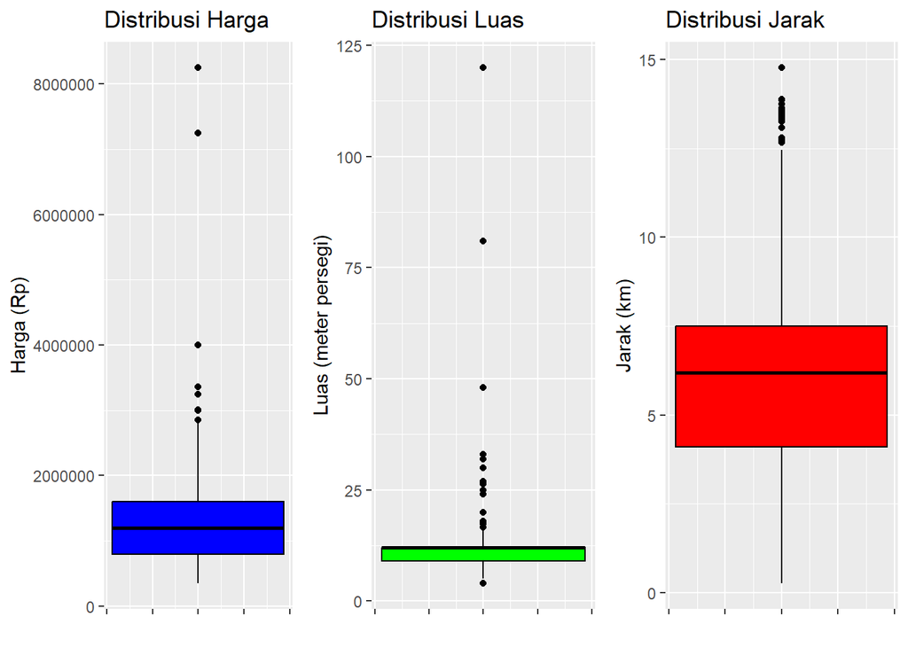

```r
library(ggplot2)
library(gridExtra)

# Create individual boxplots
boxplot_harga <- ggplot(df, aes(y = Harga)) +
  geom_boxplot(fill = "blue", color = "black") +
  labs(title = "Distribusi Harga", y = "Harga (Rp)", x = "") +
  theme(axis.text.x = element_blank())

boxplot_luas <- ggplot(df, aes(y = Luas.Kamar)) +
  geom_boxplot(fill = "green", color = "black") +
  labs(title = "Distribusi Luas", y = "Luas (meter persegi)", x = "") +
  theme(axis.text.x = element_blank())

boxplot_jarak <- ggplot(df, aes(y = UPN)) +
  geom_boxplot(fill = "red", color = "black") +
  labs(title = "Distribusi Jarak", y = "Jarak (km)", x = "") +
  theme(axis.text.x = element_blank())

# Gabungkan
grid.arrange(boxplot_harga, boxplot_luas, boxplot_jarak, ncol = 3, widths = c(1.2, 1.2, 1.2))
```

### 2.1.1 Harga Sewa

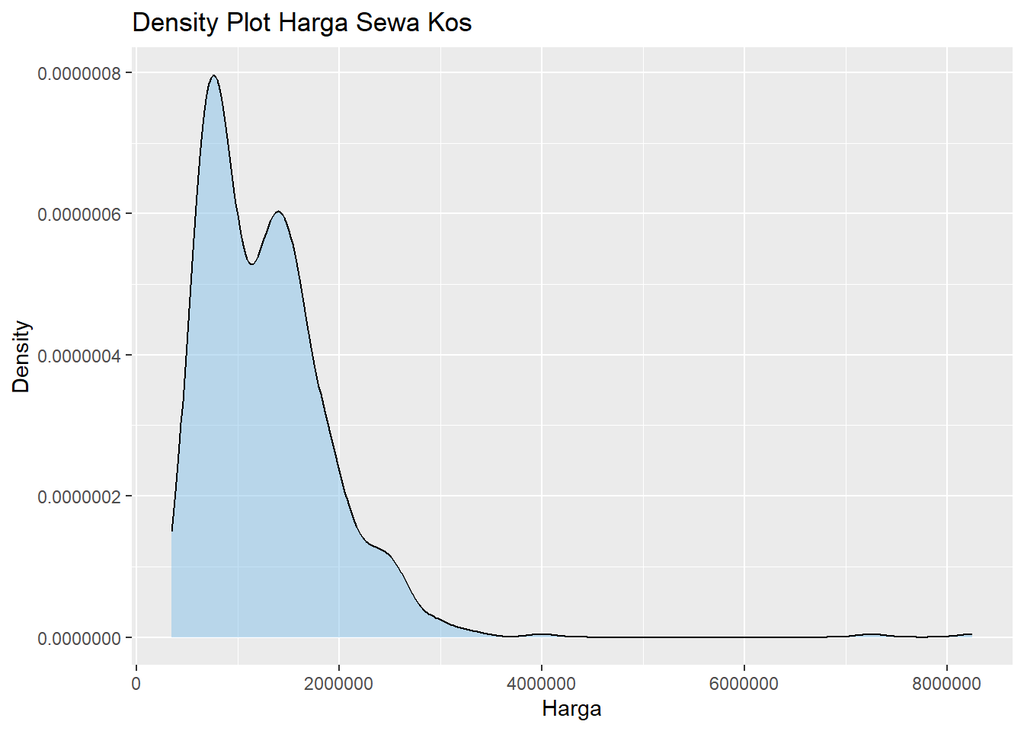

```r
# Plot density
ggplot(df, aes(x = Harga)) +
  geom_density(fill = "#85C1E9", alpha = 0.5) +
  labs(x = "Harga", y = "Density", title = "Density Plot Harga Sewa Kos")
```

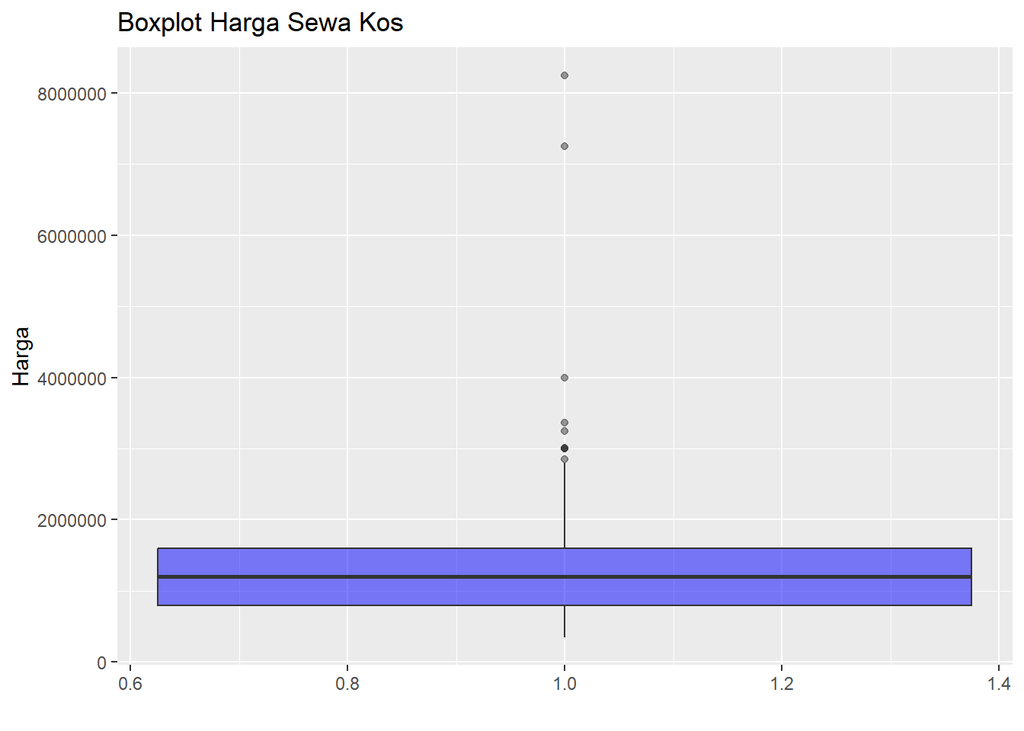

```r
# Boxplot
ggplot(df, aes(x = 1, y = Harga)) +
  geom_boxplot(fill = "blue", alpha = 0.5) +
  labs(x = "", y = "Harga", title = "Boxplot Harga Sewa Kos")
```

```r
# Hitung Quartile Pertama dan Ketiga
Q1 <- quantile(df$Harga, 0.25)
Q3 <- quantile(df$Harga, 0.75)

# Hitung Interquartile Range (IQR)
IQR <- Q3 - Q1

# Hitung Batas Bawah dan Atas untuk Outlier
lower_bound <- Q1 - 1.5 * IQR
upper_bound <- Q3 + 1.5 * IQR

# Identifikasi Outlier
outliers <- df$Harga[df$Harga < lower_bound | df$Harga > upper_bound]

# Tampilkan hasil
print(outliers)
```

```
#>  [1] 3359500 3250000 8250000 7250000 3000000 3000000 3000000 4000000 2850000
#> [10] 3010000
```

```r
# Filter dataframe untuk menghapus outlier pada Harga Sewa
df <- df[!(df$Harga < lower_bound | df$Harga > upper_bound), ]

tail(df)
```

|  | X | Link | Nama | Lokasi | Harga | Jenis | Listrik | Luas.Kamar | K.Mandi.Dalam | AC | WiFi | Kasur | Akses.24.Jam | Panjang.Kamar | Lebar.Kamar | Maps | Latitude | Longitude | UPN |
| --- | --- | --- | --- | --- | --- | --- | --- | --- | --- | --- | --- | --- | --- | --- | --- | --- | --- | --- | --- |
| 672 | 671 | https://mamikos.com/room/kost-kota-surabaya-kost-putra-eksklusif-kost-32-tipe-single-bed-sukolilo-surabaya-2?redirection_source=list%20kos%20result | Kost 32 Tipe Single Bed Sukolilo Surabaya | Sukolilo | 1800000 | Putra | Tidak termasuk listrik | 12.0 | Yes | Yes | Yes | Yes | Yes | 3.0 | 4 | https://maps.google.com/maps?z=7&q=-7.2940938428085,112.80368607491 | -7.294094 | 112.8037 | 4.611752 |
| 673 | 672 | https://mamikos.com/room/kost-kota-surabaya-kost-putra-eksklusif-kost-griyaku-deluxe-sukolilo-surabaya?redirection_source=list%20kos%20result | Kost Griyaku Deluxe Sukolilo Surabaya | Sukolilo | 1750000 | Putra | Tidak termasuk listrik | 7.5 | Yes | Yes | Yes | Yes | Yes | 2.5 | 3 | https://maps.google.com/maps?z=7&q=-7.292635,112.806338 | -7.292635 | 112.8063 | 4.873151 |
| 674 | 673 | https://mamikos.com/room/kost-surabaya-kost-putra-murah-kost-bu-antono-tmb-7-tipe-a-mulyorejo-surabaya?redirection_source=list%20kos%20result | Kost Bu Antono TMB 7 Tipe A Mulyorejo Surabaya | Mulyorejo | 550000 | Putra | Tidak termasuk listrik | 6.0 | No | No | No | Yes | Yes | 2.0 | 3 | https://maps.google.com/maps?z=7&q=-7.276612,112.786996 | -7.276612 | 112.7870 | 6.248669 |
| 675 | 674 | https://mamikos.com/room/kost-kota-surabaya-kost-putri-eksklusif-kost-griya-putri-bu-lidia-sukolilo-surabaya?redirection_source=list%20kos%20result | Kost Griya Putri Bu Lidia Sukolilo Surabaya | Sukolilo | 2599999 | Putri | Tidak termasuk listrik | 12.0 | Yes | Yes | Yes | Yes | Yes | 3.0 | 4 | https://maps.google.com/maps?z=7&q=-7.292577,112.808134 | -7.292577 | 112.8081 | 4.961695 |
| 676 | 675 | https://mamikos.com/room/kost-kota-surabaya-kost-putra-eksklusif-kost-veka-sukolilo-surabaya-2?redirection_source=list%20kos%20result | Kost Veka Sukolilo Surabaya | Sukolilo | 1600000 | Putra | Tidak termasuk listrik | 9.0 | Yes | Yes | Yes | Yes | Yes | 3.0 | 3 | https://maps.google.com/maps?z=7&q=-7.2893543,112.80338 | -7.289354 | 112.8034 | 5.096042 |
| 677 | 676 | https://mamikos.com/room/kost-kota-surabaya-kost-putra-eksklusif-kost-griya-siswa-mulyorejo-surabaya?redirection_source=list%20kos%20result | Kost Griya Siswa Mulyorejo Surabaya | Mulyorejo | 1400000 | Putra | Tidak termasuk listrik | 12.0 | Yes | Yes | Yes | Yes | Yes | 3.0 | 4 | https://maps.google.com/maps?z=7&q=-7.2893543,112.80338 | -7.289354 | 112.8034 | 5.096042 |

```r
nrow(df)
```

```
#> [1] 667
```

### 2.1.2 Luas Kamar

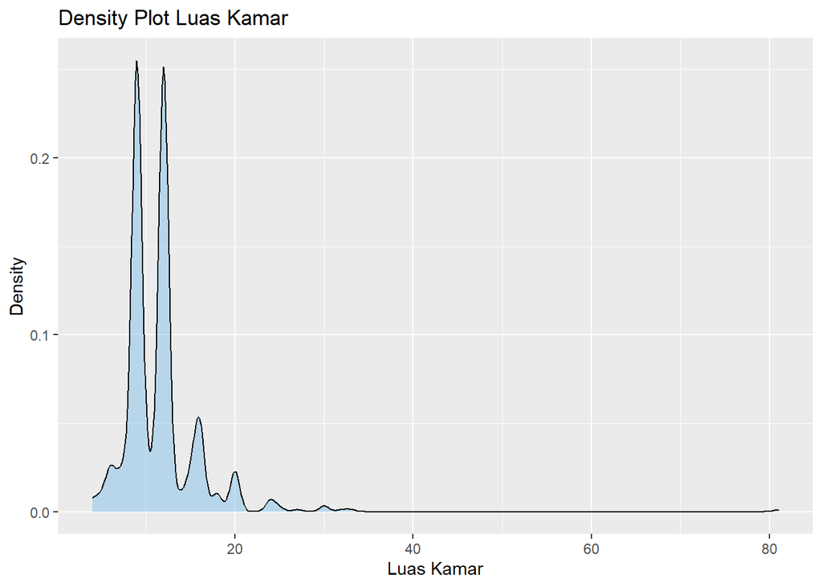

```r
# Plot density
ggplot(df, aes(x = Luas.Kamar)) +
  geom_density(fill = "#85C1E9", alpha = 0.5) +
  labs(x = "Luas Kamar", y = "Density", title = "Density Plot Luas Kamar")
```

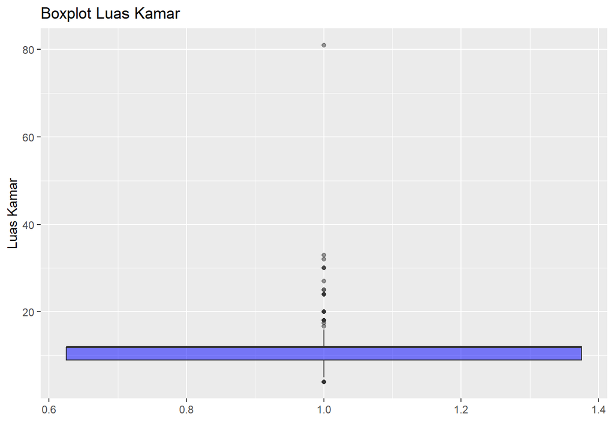

```r
# Boxplot
ggplot(df, aes(x = 1, y = Luas.Kamar)) +
  geom_boxplot(fill = "blue", alpha = 0.5) +
  labs(x = "", y = "Luas Kamar", title = "Boxplot Luas Kamar")
```

```r
# Hitung Quartile Pertama dan Ketiga
Q1 <- quantile(df$Luas.Kamar, 0.25, na.rm = TRUE)
Q3 <- quantile(df$Luas.Kamar, 0.75, na.rm = TRUE)

# Hitung Interquartile Range (IQR)
IQR <- Q3 - Q1

# Hitung Batas Bawah dan Atas untuk Outlier
lower_bound <- Q1 - 1.5 * IQR
upper_bound <- Q3 + 1.5 * IQR

# Identifikasi Outlier
outliers <- df$Luas.Kamar[df$Luas.Kamar < lower_bound | df$Luas.Kamar > upper_bound]

# Tampilkan hasil
print(outliers)
```

```
#>  [1] 20.00 20.00 20.00 24.00 20.00 20.00 17.39 16.65 20.00  4.00 30.00 18.00
#> [13]  4.00 18.00 18.00 20.00 18.00 20.00 18.00 24.00 27.00  4.00 24.00 25.00
#> [25] 20.00  4.00 20.00 25.00 20.00 33.00 18.00 24.00 30.00 20.00 20.00 20.00
#> [37]  4.00 18.00 18.00 20.00 20.00 20.00 81.00 18.00 20.00 20.00 30.00 32.00
#> [49] 24.00  4.00 24.00 20.00 20.00
```

```r
df[df["Luas.Kamar"]>50]
```

```
#>  [1] "500"
#>  [2] "https://mamikos.com/room/kost-kota-surabaya-kost-campur-murah-kost-ibu-mj-dukuhpakis-surabaya?redirection_source=list%20kos%20result"
#>  [3] "Kost Ibu MJ Dukuhpakis Surabaya"
#>  [4] "Dukuh Pakis"
#>  [5] " 820000"
#>  [6] "Campur"
#>  [7] "Tidak termasuk listrik"
#>  [8] "81.00"
#>  [9] "Yes"
#> [10] "No"
#> [11] "No"
#> [12] "Yes"
#> [13] "Yes"
#> [14] "9.0"
#> [15] "9.0"
#> [16] "https://maps.google.com/maps?z=7&q=-7.2834580218784,112.67872430384"
#> [17] "-7.283458"
#> [18] "112.6787"
#> [19] "13.3042876"
```

**Dalam proses ini hanya akan dihapus data indekos dengan luas kamar 81 (karena setelah dilakukan pengecekan ini adalah anomali)**

[figure not shown]

```r
# Filter dataframe untuk menghapus data luas kamar > 80
df <- df[!(df$Luas.Kamar>80), ]
```

```r
nrow(df)
```

```
#> [1] 666
```

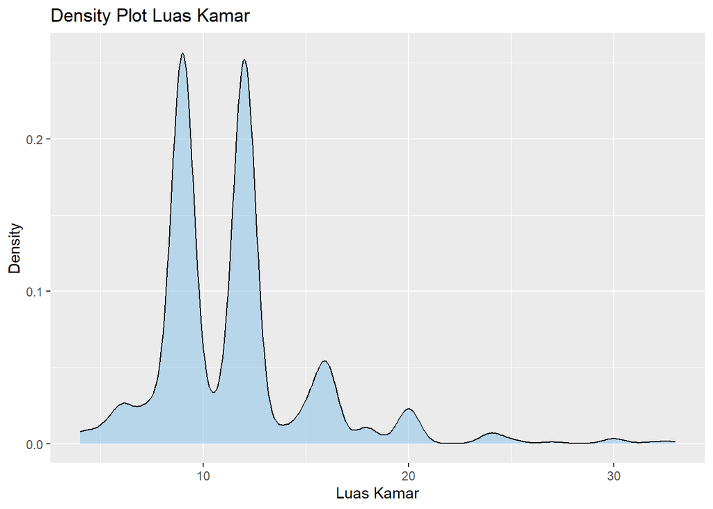

```r
# Plot density
ggplot(df, aes(x = Luas.Kamar)) +
  geom_density(fill = "#85C1E9", alpha = 0.5) +
  labs(x = "Luas Kamar", y = "Density", title = "Density Plot Luas Kamar")
```

### 2.1.3 Jarak ke UPN

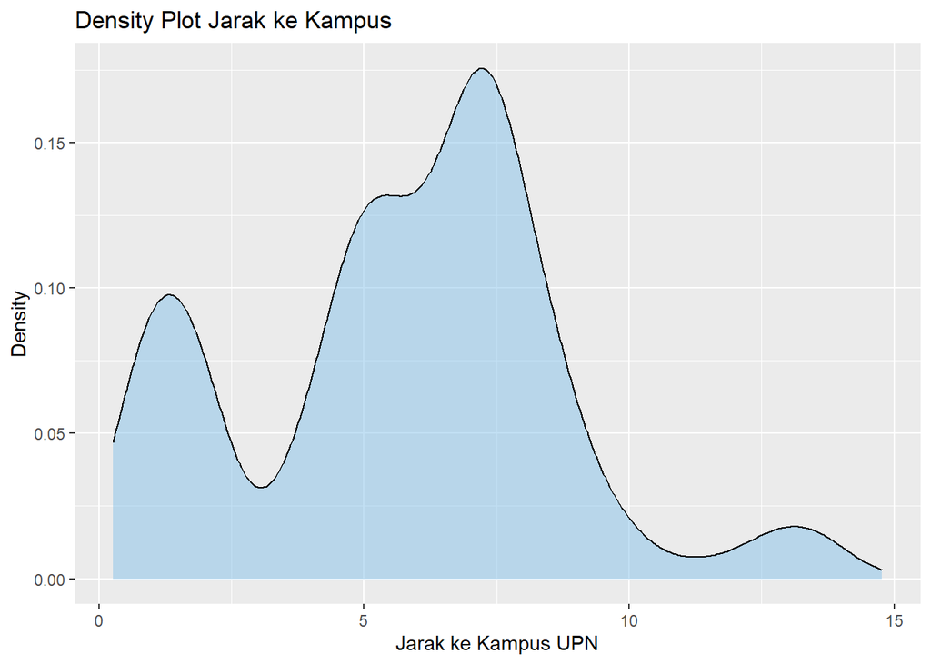

```r
# Plot density
ggplot(df, aes(x = UPN)) +
  geom_density(fill = "#85C1E9", alpha = 0.5) +
  labs(x = "Jarak ke Kampus UPN", y = "Density", title = "Density Plot Jarak ke Kampus")
```

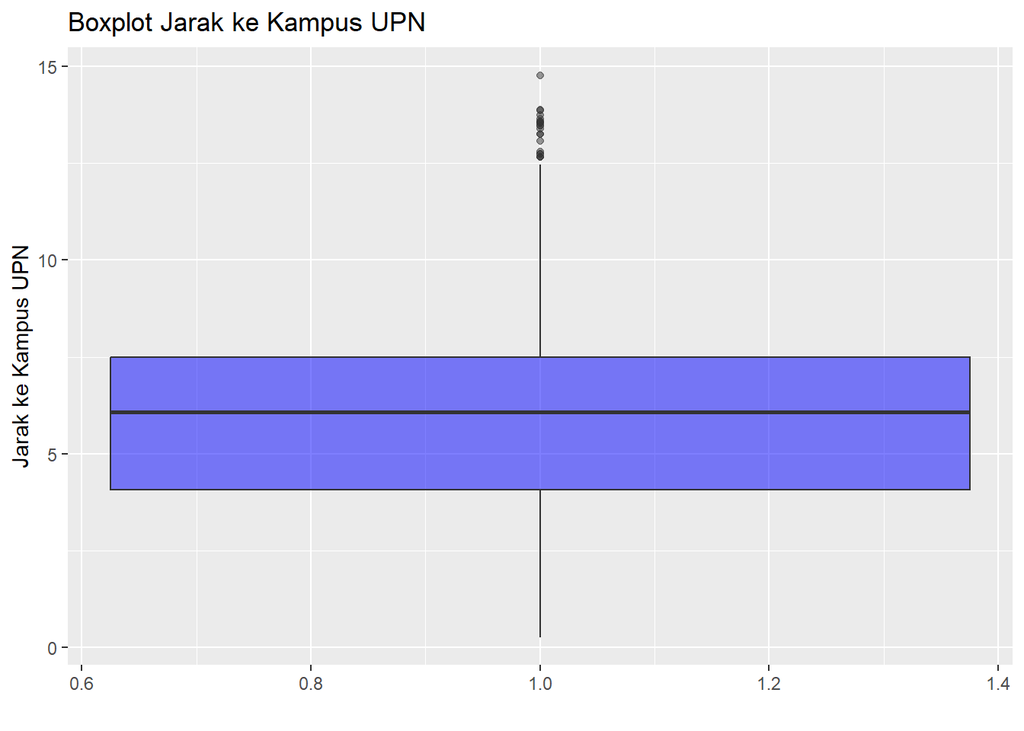

```r
# Boxplot
ggplot(df, aes(x = 1, y = UPN)) +
  geom_boxplot(fill = "blue", alpha = 0.5) +
  labs(x = "", y = "Jarak ke Kampus UPN", title = "Boxplot Jarak ke Kampus UPN")
```

```r
# Hitung Quartile Pertama dan Ketiga
Q1 <- quantile(df$UPN, 0.25)
Q3 <- quantile(df$UPN, 0.75)

# Hitung Interquartile Range (IQR)
IQR <- Q3 - Q1

# Hitung Batas Bawah dan Atas untuk Outlier
lower_bound <- Q1 - 1.5 * IQR
upper_bound <- Q3 + 1.5 * IQR

# Identifikasi Outlier
outliers <- df$UPN[df$UPN < lower_bound | df$UPN > upper_bound]

# Tampilkan hasil
print(outliers)
```

```
#>  [1] 13.74165 12.66270 12.66270 13.64085 13.56095 12.67219 13.59427 12.80132
#>  [9] 13.07870 13.52525 13.55542 13.24867 13.47645 13.25906 14.77528 13.85374
#> [17] 13.87575 12.73635 13.39379 12.74611 13.46274
```

```r
# Filter dataframe untuk menghapus outlier pada data Jarak ke Kampus UPN
df <- df[!(df$UPN < lower_bound | df$UPN > upper_bound), ]

tail(df)
```

|  | X | Link | Nama | Lokasi | Harga | Jenis | Listrik | Luas.Kamar | K.Mandi.Dalam | AC | WiFi | Kasur | Akses.24.Jam | Panjang.Kamar | Lebar.Kamar | Maps | Latitude | Longitude | UPN |
| --- | --- | --- | --- | --- | --- | --- | --- | --- | --- | --- | --- | --- | --- | --- | --- | --- | --- | --- | --- |
| 672 | 671 | https://mamikos.com/room/kost-kota-surabaya-kost-putra-eksklusif-kost-32-tipe-single-bed-sukolilo-surabaya-2?redirection_source=list%20kos%20result | Kost 32 Tipe Single Bed Sukolilo Surabaya | Sukolilo | 1800000 | Putra | Tidak termasuk listrik | 12.0 | Yes | Yes | Yes | Yes | Yes | 3.0 | 4 | https://maps.google.com/maps?z=7&q=-7.2940938428085,112.80368607491 | -7.294094 | 112.8037 | 4.611752 |
| 673 | 672 | https://mamikos.com/room/kost-kota-surabaya-kost-putra-eksklusif-kost-griyaku-deluxe-sukolilo-surabaya?redirection_source=list%20kos%20result | Kost Griyaku Deluxe Sukolilo Surabaya | Sukolilo | 1750000 | Putra | Tidak termasuk listrik | 7.5 | Yes | Yes | Yes | Yes | Yes | 2.5 | 3 | https://maps.google.com/maps?z=7&q=-7.292635,112.806338 | -7.292635 | 112.8063 | 4.873151 |
| 674 | 673 | https://mamikos.com/room/kost-surabaya-kost-putra-murah-kost-bu-antono-tmb-7-tipe-a-mulyorejo-surabaya?redirection_source=list%20kos%20result | Kost Bu Antono TMB 7 Tipe A Mulyorejo Surabaya | Mulyorejo | 550000 | Putra | Tidak termasuk listrik | 6.0 | No | No | No | Yes | Yes | 2.0 | 3 | https://maps.google.com/maps?z=7&q=-7.276612,112.786996 | -7.276612 | 112.7870 | 6.248669 |
| 675 | 674 | https://mamikos.com/room/kost-kota-surabaya-kost-putri-eksklusif-kost-griya-putri-bu-lidia-sukolilo-surabaya?redirection_source=list%20kos%20result | Kost Griya Putri Bu Lidia Sukolilo Surabaya | Sukolilo | 2599999 | Putri | Tidak termasuk listrik | 12.0 | Yes | Yes | Yes | Yes | Yes | 3.0 | 4 | https://maps.google.com/maps?z=7&q=-7.292577,112.808134 | -7.292577 | 112.8081 | 4.961695 |
| 676 | 675 | https://mamikos.com/room/kost-kota-surabaya-kost-putra-eksklusif-kost-veka-sukolilo-surabaya-2?redirection_source=list%20kos%20result | Kost Veka Sukolilo Surabaya | Sukolilo | 1600000 | Putra | Tidak termasuk listrik | 9.0 | Yes | Yes | Yes | Yes | Yes | 3.0 | 3 | https://maps.google.com/maps?z=7&q=-7.2893543,112.80338 | -7.289354 | 112.8034 | 5.096042 |
| 677 | 676 | https://mamikos.com/room/kost-kota-surabaya-kost-putra-eksklusif-kost-griya-siswa-mulyorejo-surabaya?redirection_source=list%20kos%20result | Kost Griya Siswa Mulyorejo Surabaya | Mulyorejo | 1400000 | Putra | Tidak termasuk listrik | 12.0 | Yes | Yes | Yes | Yes | Yes | 3.0 | 4 | https://maps.google.com/maps?z=7&q=-7.2893543,112.80338 | -7.289354 | 112.8034 | 5.096042 |

```r
nrow(df)
```

```
#> [1] 645
```

### 2.1.4 Korelasi

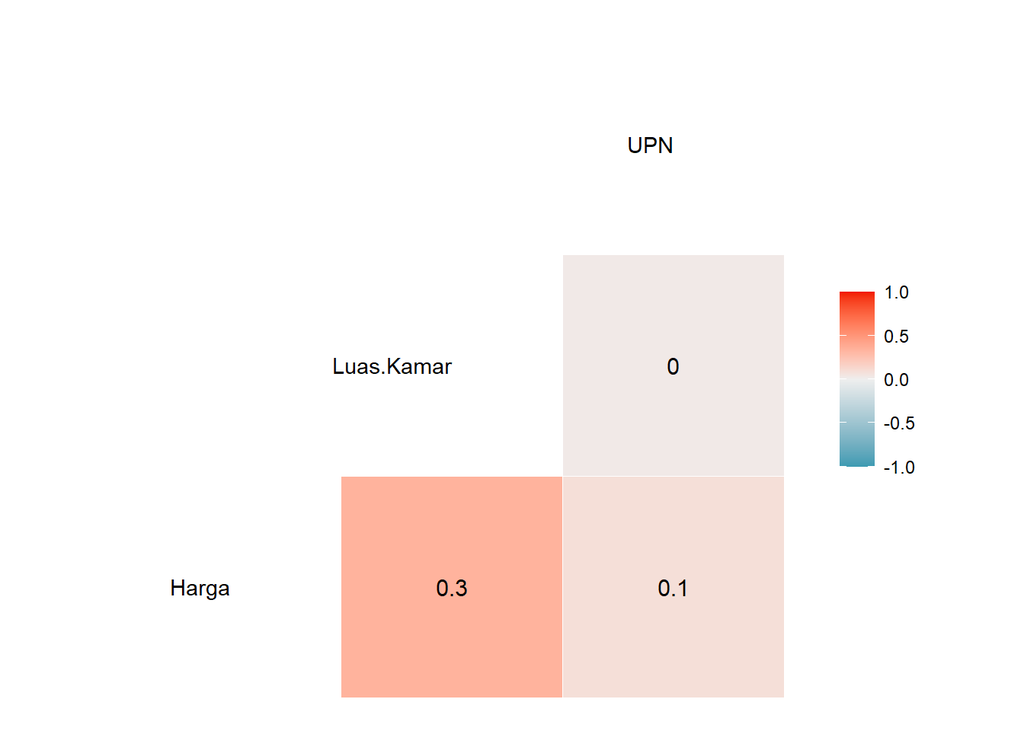

```r
library(GGally)

# korelasi sebelum PCA
ggcorr(df[, c("Harga", "Luas.Kamar", "UPN")], label = T, hjust =1)
```

## 2.2 Eksplorasi Data Kategorik

### 2.2.1 Persentase Ketersediaan Fasilitas

```r
# Menghitung jumlah total properti
total_properti <- nrow(df)

# Menghitung jumlah properti yang menyediakan setiap fasilitas
jumlah_k_mandi_dalam <- sum(df$'K.Mandi.Dalam' == 'Yes')
jumlah_ac <- sum(df$AC == 'Yes')
jumlah_wifi <- sum(df$WiFi == 'Yes')
jumlah_kasur <- sum(df$Kasur == 'Yes')
jumlah_akses_24_jam <- sum(df$'Akses.24.Jam' == 'Yes')
jumlah_listrik_termasuk <- sum(df$Listrik == 'Termasuk listrik')

# Menghitung persentase ketersediaan fasilitas
persentase_k_mandi_dalam <- (jumlah_k_mandi_dalam / total_properti) * 100
persentase_ac <- (jumlah_ac / total_properti) * 100
persentase_wifi <- (jumlah_wifi / total_properti) * 100
persentase_kasur <- (jumlah_kasur / total_properti) * 100
persentase_akses_24_jam <- (jumlah_akses_24_jam / total_properti) * 100
persentase_listrik_termasuk <- (jumlah_listrik_termasuk / total_properti) * 100

# Membuat dataframe untuk tabel ketersediaan fasilitas
tabel_ketersediaan <- data.frame(
  Fasilitas = c('K. Mandi Dalam', 'AC', 'WiFi', 'Kasur', 'Akses 24 Jam', 'Informasi Termasuk Listrik'),
  'Persentase Ketersediaan (%)' = c(
    persentase_k_mandi_dalam,
    persentase_ac,
    persentase_wifi,
    persentase_kasur,
    persentase_akses_24_jam,
    persentase_listrik_termasuk
  )
)

# Tampilkan dataframe
print(tabel_ketersediaan)
```

```
#>                    Fasilitas Persentase.Ketersediaan....
#> 1             K. Mandi Dalam                    53.17829
#> 2                         AC                    59.68992
#> 3                       WiFi                    84.18605
#> 4                      Kasur                    95.34884
#> 5               Akses 24 Jam                    72.55814
#> 6 Informasi Termasuk Listrik                    34.72868
```

📌 Kolom terkait fasilitas WiFI, ‘Kasur’, dan Akses 24 Jam nantinya tidak akan digunakan dalam pemodelan karena mayoritas kos (>70% kos) menyediakan fasilitas tersebut. Hal ini dilakukan untuk menghindari bias dalam proses klasterisasi.

```r
# Menghapus level yang tidak digunakan
df$Lokasi <- droplevels(df$Lokasi)
```

```r
table(df$Lokasi)
```

```
#>
#>      Dukuh Pakis         Gayungan          Genteng           Gubeng
#>               12               28               18              123
#>     Gunung Anyar        Jambangan    Karang Pilang        Mulyorejo
#>               46               21                5               52
#>          Rungkut         Sukolilo       Tambaksari        Tegalsari
#>               87              127               34               10
#> Tenggilis Mejoyo             Waru           Wiyung         Wonocolo
#>                4                7                7               23
#>        Wonokromo
#>               41
```

```r
# Sebelum filter lokasi
nrow(df)
```

```
#> [1] 645
```

```r
# Daftar lokasi Surabaya Timur
sby_timur <- c('Gubeng', 'Gunung Anyar', 'Sukolilo', 'Tambaksari', 'Mulyorejo', 'Rungkut', 'Tenggilis Mejoyo')

# Filter lokasi sby_timur
df <- df[df$Lokasi %in% sby_timur, ]
```

```r
# Setelah filter lokasi
nrow(df)
```

```
#> [1] 473
```

**473 ROW DATA DIGUNAKAN UNTUK PEMODELAN**

```r
df$Lokasi <- droplevels(df$Lokasi)
table(df$Lokasi)
```

```
#>
#>           Gubeng     Gunung Anyar        Mulyorejo          Rungkut
#>              123               46               52               87
#>         Sukolilo       Tambaksari Tenggilis Mejoyo
#>              127               34                4
```

```r
# Reset index
rownames(df) <- seq(nrow(df))
```

# 3 Pemodelan

```r
# Standarisasi kolom numerik (Harga, Luas.Kamar, dan UPN)
df <- df %>%
  mutate(
    Harga.Scale = as.numeric(scale(Harga)),
    Luas.Kamar.Scale = as.numeric(scale(Luas.Kamar)),
    UPN.Scale = as.numeric(scale(UPN))
  )

tail(df)
```

|  | X | Link | Nama | Lokasi | Harga | Jenis | Listrik | Luas.Kamar | K.Mandi.Dalam | AC | WiFi | Kasur | Akses.24.Jam | Panjang.Kamar | Lebar.Kamar | Maps | Latitude | Longitude | UPN | Harga.Scale | Luas.Kamar.Scale | UPN.Scale |
| --- | --- | --- | --- | --- | --- | --- | --- | --- | --- | --- | --- | --- | --- | --- | --- | --- | --- | --- | --- | --- | --- | --- |
| 468 | 671 | https://mamikos.com/room/kost-kota-surabaya-kost-putra-eksklusif-kost-32-tipe-single-bed-sukolilo-surabaya-2?redirection_source=list%20kos%20result | Kost 32 Tipe Single Bed Sukolilo Surabaya | Sukolilo | 1800000 | Putra | Tidak termasuk listrik | 12.0 | Yes | Yes | Yes | Yes | Yes | 3.0 | 4 | https://maps.google.com/maps?z=7&q=-7.2940938428085,112.80368607491 | -7.294094 | 112.8037 | 4.611752 | 1.0776814 | 0.1954194 | -0.1000544524 |
| 469 | 672 | https://mamikos.com/room/kost-kota-surabaya-kost-putra-eksklusif-kost-griyaku-deluxe-sukolilo-surabaya?redirection_source=list%20kos%20result | Kost Griyaku Deluxe Sukolilo Surabaya | Sukolilo | 1750000 | Putra | Tidak termasuk listrik | 7.5 | Yes | Yes | Yes | Yes | Yes | 2.5 | 3 | https://maps.google.com/maps?z=7&q=-7.292635,112.806338 | -7.292635 | 112.8063 | 4.873151 | 0.9827758 | -0.9939274 | -0.0001261087 |
| 470 | 673 | https://mamikos.com/room/kost-surabaya-kost-putra-murah-kost-bu-antono-tmb-7-tipe-a-mulyorejo-surabaya?redirection_source=list%20kos%20result | Kost Bu Antono TMB 7 Tipe A Mulyorejo Surabaya | Mulyorejo | 550000 | Putra | Tidak termasuk listrik | 6.0 | No | No | No | Yes | Yes | 2.0 | 3 | https://maps.google.com/maps?z=7&q=-7.276612,112.786996 | -7.276612 | 112.7870 | 6.248669 | -1.2949599 | -1.3903763 | 0.5257104387 |
| 471 | 674 | https://mamikos.com/room/kost-kota-surabaya-kost-putri-eksklusif-kost-griya-putri-bu-lidia-sukolilo-surabaya?redirection_source=list%20kos%20result | Kost Griya Putri Bu Lidia Sukolilo Surabaya | Sukolilo | 2599999 | Putri | Tidak termasuk listrik | 12.0 | Yes | Yes | Yes | Yes | Yes | 3.0 | 4 | https://maps.google.com/maps?z=7&q=-7.292577,112.808134 | -7.292577 | 112.8081 | 4.961695 | 2.5961700 | 0.1954194 | 0.0337227411 |
| 472 | 675 | https://mamikos.com/room/kost-kota-surabaya-kost-putra-eksklusif-kost-veka-sukolilo-surabaya-2?redirection_source=list%20kos%20result | Kost Veka Sukolilo Surabaya | Sukolilo | 1600000 | Putra | Tidak termasuk listrik | 9.0 | Yes | Yes | Yes | Yes | Yes | 3.0 | 3 | https://maps.google.com/maps?z=7&q=-7.2893543,112.80338 | -7.289354 | 112.8034 | 5.096042 | 0.6980588 | -0.5974785 | 0.0850811387 |
| 473 | 676 | https://mamikos.com/room/kost-kota-surabaya-kost-putra-eksklusif-kost-griya-siswa-mulyorejo-surabaya?redirection_source=list%20kos%20result | Kost Griya Siswa Mulyorejo Surabaya | Mulyorejo | 1400000 | Putra | Tidak termasuk listrik | 12.0 | Yes | Yes | Yes | Yes | Yes | 3.0 | 4 | https://maps.google.com/maps?z=7&q=-7.2893543,112.80338 | -7.289354 | 112.8034 | 5.096042 | 0.3184362 | 0.1954194 | 0.0850811387 |

```r
table(df$Lokasi)
```

```
#>
#>           Gubeng     Gunung Anyar        Mulyorejo          Rungkut
#>              123               46               52               87
#>         Sukolilo       Tambaksari Tenggilis Mejoyo
#>              127               34                4
```

Bisa diperhatikan bahwa terdapat banyak kategori lokasi dan sebarannya tidak merata. Oleh karena itu, kolom Lokasi (kategori) tidak akan digunakan dalam pemodelan (karena sudah diwakilkan juga dengan informais maps nantinya ketika deployment)

> TERSISA 7 VARIABEL (3 NUMERIK + 4 KATEGORIK) UNTUK NANTINYA DILAKUKAN PEMODELAN KLASTER

```r
selected_col <- c("Harga.Scale", "Luas.Kamar.Scale", "UPN.Scale",
                "Jenis", "Listrik", "K.Mandi.Dalam", "AC")

df[, selected_col]
```

|  | Harga.Scale | Luas.Kamar.Scale | UPN.Scale | Jenis | Listrik | K.Mandi.Dalam | AC |
| --- | --- | --- | --- | --- | --- | --- | --- |
| 1 | -0.66858258 | -1.6546756 | -1.1282592249 | Putri | Tidak termasuk listrik | No | No |
| 2 | 0.08117207 | -1.6546756 | -1.1282592249 | Putri | Tidak termasuk listrik | No | Yes |
| 3 | -0.58316749 | -1.3903763 | -1.1282592249 | Putri | Tidak termasuk listrik | No | No |
| 4 | 2.45381338 | 2.3098138 | -1.1951117385 | Putri | Tidak termasuk listrik | Yes | Yes |
| 5 | 1.50475686 | 1.2526166 | -1.1951117385 | Putri | Tidak termasuk listrik | Yes | Yes |
| 6 | 2.07419077 | 2.3098138 | -1.1951117385 | Putri | Tidak termasuk listrik | Yes | Yes |
| 7 | 0.22353055 | -0.5974785 | -1.2639366378 | Putra | Tidak termasuk listrik | Yes | Yes |
| 8 | -0.06118640 | -0.5974785 | -1.5824696681 | Putra | Tidak termasuk listrik | No | Yes |
| 9 | 1.45730403 | 2.3098138 | -1.4405236567 | Campur | Tidak termasuk listrik | Yes | Yes |
| 10 | 0.12862490 | -0.5974785 | -1.5460843154 | Putri | Tidak termasuk listrik | Yes | Yes |

[output cut: 463 more lines]

## 3.1 K-Prototype

### 3.1.1 Penentuan Bnayak Cluster (Kelompok)

#### 3.1.1.1 Elbow Method

```r
library(clustMixType)
```

```r
set.seed(7567)

# Fungsi untuk menghitung WSS
wss <- function(k) {
  kproto_model <- kproto(df[, selected_col], k)
  sum(kproto_model$tot.withinss)
}

# Menghitung WSS untuk berbagai nilai k
k.values <- 1:9
wss.values <- sapply(k.values, wss)
```

[output not shown]

[output cut: 43 more lines]

[output not shown]

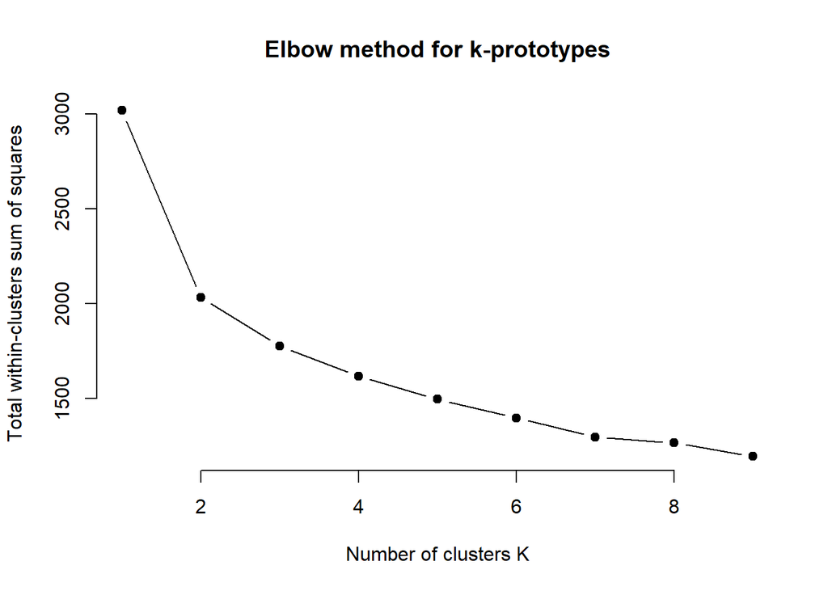

```r
# Membuat grafik elbow
elbow1 <- plot(k.values, wss.values, type="b", pch = 19, frame = FALSE,
     xlab="Number of clusters K",
     ylab="Total within-clusters sum of squares",
     main="Elbow method for k-prototypes")
```

#### 3.1.1.2 Silhouette Method

```r
set.seed(7567)

# Fungsi untuk pemodelan k-prototypes
kproto_wrapper <- function(k, df, selected_col) {
  kproto_model <- kproto(df[, selected_col], k)
  return(kproto_model)
}

# Fungsi untuk menghitung nilai Siluet rata-rata menggunakan jarak default k-prototypes
avg_sil <- function(k, df) {
  kproto_model <- kproto(df, k)
  clusters <- kproto_model$cluster
  silhouette_score <- silhouette(clusters, dist(kproto_model$dists))
  mean(silhouette_score[, 3])
}

# Menghitung nilai Siluet untuk berbagai nilai k
k.values <- 2:9
sil_values <- sapply(k.values, function(k) avg_sil(k, df[, selected_col]))
```

[output not shown]

[output cut: 32 more lines]

[output not shown]

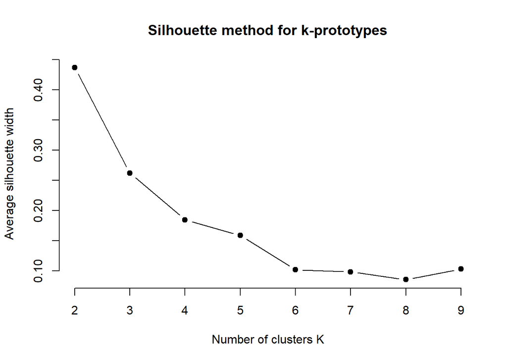

```r
# Membuat grafik untuk nilai Siluet
sil1 <- plot(k.values, sil_values, type="b", pch = 19, frame = FALSE,
     xlab="Number of clusters K",
     ylab="Average silhouette width",
     main="Silhouette method for k-prototypes")
```

```r
sil_values
```

```
#> [1] 0.43669289 0.26189469 0.18430362 0.15853891 0.10170730 0.09802517 0.08522543
#> [8] 0.10263112
```

### 3.1.2 Klasterisasi K-Prototype dengan K = 2

**Kelompok 1**

```r
# Pilih k = 2
set.seed(7567)
k <- 2

# Melakukan clustering untuk k = 2
kproto_model <- kproto(df[, selected_col], k)
```

```
#> # NAs in variables:
#>      Harga.Scale Luas.Kamar.Scale        UPN.Scale            Jenis
#>                0                0                0                0
#>          Listrik    K.Mandi.Dalam               AC
#>                0                0                0
#> 0 observation(s) with NAs.
#>
#> Estimated lambda: 1.955827
#>
#> 0 observation(s) with NAs.
```

```r
clusters <- kproto_model$cluster

# Menampilkan summary dari data klaster 1
summary(df[clusters == 1, c("Harga", "Luas.Kamar", "UPN",
                  "Jenis", "Listrik", "K.Mandi.Dalam", "AC")])
```

```
#>      Harga           Luas.Kamar         UPN            Jenis
#>  Min.   : 500000   Min.   : 4.00   Min.   :0.2662   Campur: 73
#>  1st Qu.:1250000   1st Qu.: 9.00   1st Qu.:1.7465   Putra : 66
#>  Median :1500000   Median :12.00   Median :5.1301   Putri :133
#>  Mean   :1556476   Mean   :12.45   Mean   :4.7968
#>  3rd Qu.:1800000   3rd Qu.:15.00   3rd Qu.:7.1083
#>  Max.   :2800000   Max.   :32.00   Max.   :9.8522
#>                    Listrik    K.Mandi.Dalam   AC
#>  Termasuk listrik      : 32   No : 65       No : 20
#>  Tidak termasuk listrik:240   Yes:207       Yes:252
#>
#>
#>
#>
```

**Kelompok 2**

```r
# Menampilkan summary dari data klaster 2
summary(df[clusters == 2, c("Harga", "Luas.Kamar", "UPN",
                  "Jenis", "Listrik", "K.Mandi.Dalam", "AC")])
```

```
#>      Harga           Luas.Kamar          UPN            Jenis
#>  Min.   : 350000   Min.   : 4.000   Min.   :0.6006   Campur: 17
#>  1st Qu.: 650000   1st Qu.: 9.000   1st Qu.:2.2629   Putra : 72
#>  Median : 750000   Median : 9.000   Median :5.0613   Putri :112
#>  Mean   : 793463   Mean   : 9.651   Mean   :4.9773
#>  3rd Qu.: 900000   3rd Qu.:12.000   3rd Qu.:7.2224
#>  Max.   :1700000   Max.   :20.000   Max.   :9.9287
#>                    Listrik    K.Mandi.Dalam   AC
#>  Termasuk listrik      :131   No :171       No :173
#>  Tidak termasuk listrik: 70   Yes: 30       Yes: 28
#>
#>
#>
#>
```

## 3.2 PAM-Gower

Secara garis besar akan ada 3 langkah yang nantinya akan dilakukan, yaitu:

- Perhitungan jarak antar observasi data
- Penentuan jumlah cluster
- Clustering

### 3.2.1 Gower Distance

Metode Gower Distance nantinya akan melakukan perbandingan pada setiap observasi data yang ada terhadap data-data yang lainnya, dengan cara melakukan perhitungan skala antara kedua observasi yang dibandingkan dengan rentan 0 sampai 1. Jika hasil dari perbandingannya mendekati 0 maka bisa dibilang kedua data tersebut identik atau jarak antara kedua observasi tersebut berdekatan, begitu juga sebaliknya, jika rentan perbandingannya mendekati 1 bisa dibilang kedua data tersebut tidak identik atau jarak antara kedua observasi tersebut berjauhan.

Di R, metode Gower Distance tersimpan pada `library(cluster)` dan fungsi yang bisa digunakan adalah `daisy()`. Pada fungsi tersebut nantinya akan ada 2 parameter yang bisa diisi, yaitu:

- x: Data frame yang ingin digunakan
- metric: Metode apa yang ingin digunakan, karena kita akan menggunakan metode Gower Distance, kita bisa isi dengan “gower”.

```r
glimpse(df[, selected_col])
```

```
#> Rows: 473
#> Columns: 7
#> $ Harga.Scale      <dbl> -0.66858258, 0.08117207, -0.58316749, 2.45381338, 1.5…
#> $ Luas.Kamar.Scale <dbl> -1.6546756, -1.6546756, -1.3903763, 2.3098138, 1.2526…
#> $ UPN.Scale        <dbl> -1.1282592, -1.1282592, -1.1282592, -1.1951117, -1.19…
#> $ Jenis            <fct> Putri, Putri, Putri, Putri, Putri, Putri, Putra, Putr…
#> $ Listrik          <fct> Tidak termasuk listrik, Tidak termasuk listrik, Tidak…
#> $ K.Mandi.Dalam    <fct> No, No, No, Yes, Yes, Yes, Yes, No, Yes, Yes, Yes, Ye…
#> $ AC               <fct> No, Yes, No, Yes, Yes, Yes, Yes, Yes, Yes, Yes, Yes, …
```

```r
df_gower <- daisy(x = df[, selected_col],
                       metric = "gower")

# Hasil df_gower adalah nilai dissimilarity antar objek data
```

Sebagai pembuktian apakah metode Gower Distance memang bisa menempatkan data-data kita berdasarkan kemiripannya, kita bisa mencetak pasangan yang paling mirip dan berbeda dalam data kita dengan menggunakan fungsi di bawah ini.

**Contoh pasangan data yang paling identik**

```r
example <- as.matrix(df_gower)

df[, selected_col][which(example == min(example[example != min(example)]),
        arr.ind = TRUE)[1, ], ]
```

|  | Harga.Scale | Luas.Kamar.Scale | UPN.Scale | Jenis | Listrik | K.Mandi.Dalam | AC |
| --- | --- | --- | --- | --- | --- | --- | --- |
| 117 | 0.8878701 | 0.724018 | -1.229409 | Putri | Tidak termasuk listrik | Yes | Yes |
| 92 | 0.8878701 | 0.724018 | -1.229425 | Putri | Tidak termasuk listrik | Yes | Yes |

```r
baris1 <- 117
baris2 <- 92
jarak <- example[baris1, baris2]
print(jarak)
```

```
#> [1] 0.0000006207965
```

Dalam kode diatas, `min(example[example != min(example)])` bagian ini mencari nilai terkecil kedua dalam matriks example. Nilai terkecil pertama dalam matriks adalah nol (yang menunjukkan jarak suatu baris dengan dirinya sendiri). Untuk mencari pasangan data yang paling mirip, kita harus menemukan nilai terkecil selain nol.

**Contoh pasangan data yang paling tidak identik**

```r
df[, selected_col][which(example == max(example[example != max(example)]),
        arr.ind = TRUE)[1, ], ]
```

|  | Harga.Scale | Luas.Kamar.Scale | UPN.Scale | Jenis | Listrik | K.Mandi.Dalam | AC |
| --- | --- | --- | --- | --- | --- | --- | --- |
| 442 | -1.200054 | -1.918975 | 1.932524 | Putra | Termasuk listrik | No | No |
| 4 | 2.453813 | 2.309814 | -1.195112 | Putri | Tidak termasuk listrik | Yes | Yes |

```r
baris1 <- 442
baris2 <- 4
jarak <- example[baris1, baris2]
print(jarak)
```

```
#> [1] 0.8862671
```

### 3.2.2 Penentuan Banyak Cluster (Kelompok)

Tujuan dari melakukan clustering adalah menempatkan setiap observasi data yang ada ke beberapa kelompok yang sesuai dengan karakteristiknya atau bedasarkan kedekatan jarak antar setiap observasi. Pada langkah pertama kita sudah memiliki informasi jarak antar setiap observasi, kita akan memanfaatkan informasi tersebut untuk menentukan berapakah kelompok yang paling optimal.

Terdapat 3 metode yang dapat digunakan untuk menentukan jumlah kelompok yang paling optimum yaitu, Elbow Method, Silhouette Method & Gap Statistic Method. Ketiga metode tersebut dapat kita gunakan dengan menggunakan fungsi `fviz_nbclust()` dari `library(factoextra)`. Pada fungsi tersebut nantinya akan ada 3 parameter yang bisa diisi, yaitu:

- x = Data frame yang ingin digunakan
- FUNcluster = Metode pengelompokan apa yang ingin digunakan, karena kita akan menggunakan metode PAM, kita bisa isi dengan pam.
- method = Metode apa yang ingin digunakan untuk mengestimasi jumlah kelompok yang paling optimal.

#### 3.2.2.1 Elbow Method

Dengan metode pertama ini kita akan memvariasikan jumlah kelompok dengan menghitung Within Sum of Square (WSS). WSS adalah akan menghasilkan jumlah kuadrat jarak antara setiap observasi terhadap titik Medoids untuk setiap kemungkinan jumlah kelompok, fungsi fviz_nbclust() secara otomatis akan menghitung WCSS sampai dengan 10 kelompok (jumlah kelompok yang ingin dicoba hitung bisa diatur secara manual sesuai dengan kebutuhan).

Dengan bertambahnya jumlah kelompok, nilai WSS akan mulai berkurang (nilai WSS terbesar ketika K = 1). Ketika kita menganalisis grafik kita dapat melihat bahwa grafik akan berubah dengan cepat pada suatu titik dan dengan demikian menciptakan bentuk siku. Dari titik ini, grafik mulai bergerak hampir sejajar dengan sumbu X. Nilai K yang sesuai dengan titik ini adalah nilai K optimal atau jumlah kelompok yang optimal.

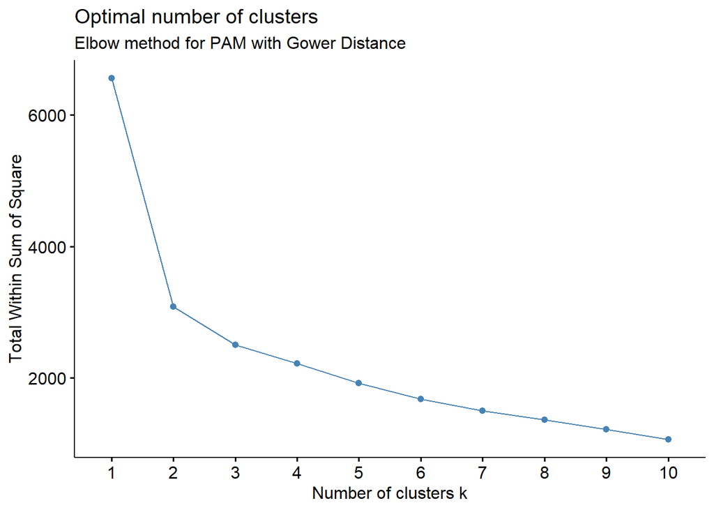

```r
set.seed(7567)

fviz_nbclust(x = as.matrix(df_gower),
             FUNcluster = pam,
             method = "wss",
             k.max=10) +
  labs(subtitle = "Elbow method for PAM with Gower Distance")
```

#### 3.2.2.2 Silhouette Method

Metode kedua yang akan dicoba untuk menentukan jumlah kelompok yang optimal adalah Silhouette Method. Metode ini akan menghitung seberapa mirip sebuah observasi dengan kelompoknya sendiri jika dibandingkan dengan nilai kelompok lainnya. Hasil dari perhitungannya akan memiliki rentan koefisien dari -1 sampai 1. Jika nanti hasilnya makin mendekati 1 maka observasi tersebut cocok dengan kelompoknya dan kurang cocok dengan kelompok tetangga, begitu juga sebaliknya, jika hasilnya makin mendekati -1 maka observasi tersebut tidak cocok dengan kelompoknya akan tetapi lebih cocok dengan kelompok tetangganya.

Berbeda dengan elbow method, makin bertambahnya jumlah kelompok, nilai hasil perhitungan metode silhouette method tidak pasti akan berkurang. Penentuan nilai kelompok yang optimal akan ditentukan berdasarkan nilai koefisien paling tinggi pada saat membagi keseluruhan observasi ke berapa banyak kelompok.

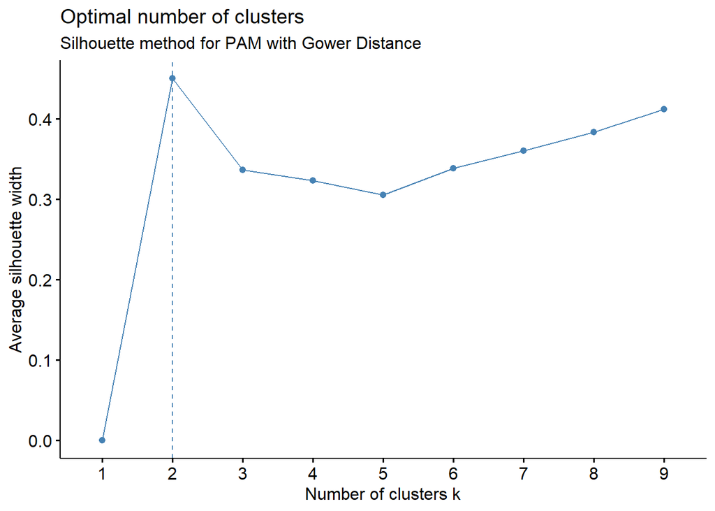

```r
set.seed(7567)

res <- fviz_nbclust(x = as.matrix(df_gower),
             FUNcluster = pam,
             k.max = 9,
             method = "silhouette") +
  labs(subtitle = "Silhouette method for PAM with Gower Distance")

print(res)
```

```r
res$data
```

| clusters | y |
| --- | --- |
| 1 | 0.0000000 |
| 2 | 0.4504005 |
| 3 | 0.3365120 |
| 4 | 0.3232972 |
| 5 | 0.3058168 |
| 6 | 0.3388005 |
| 7 | 0.3606204 |
| 8 | 0.3839391 |
| 9 | 0.4122782 |

### 3.2.3 Klasterisasi PAM-Gower dengan K = 2

```r
set.seed(7567)
pam_fit2 <- pam(x = df_gower,
               k = 2)
```

```r
pam_fit2$medoids
```

```
#> [1] "377" "325"
```

```r
df[pam_fit2$medoids, c("Harga", "Luas.Kamar", "UPN",
                  "Jenis", "Listrik", "K.Mandi.Dalam", "AC")]
```

|  | Harga | Luas.Kamar | UPN | Jenis | Listrik | K.Mandi.Dalam | AC |
| --- | --- | --- | --- | --- | --- | --- | --- |
| 377 | 700000 | 9 | 5.245627 | Putri | Termasuk listrik | No | No |
| 325 | 1500000 | 12 | 4.485416 | Putri | Tidak termasuk listrik | Yes | Yes |

```r
pam2_results <- df[,c("Harga", "Luas.Kamar", "UPN",
                  "Jenis", "Listrik", "K.Mandi.Dalam", "AC")]  %>%
  mutate(cluster = pam_fit2$clustering) %>%
  group_by(cluster) %>%
  do(the_summary = summary(.))
```

```r
pam2_results$the_summary[[1]]
```

```
#>      Harga           Luas.Kamar          UPN            Jenis
#>  Min.   : 350000   Min.   : 4.000   Min.   :0.6006   Campur:15
#>  1st Qu.: 650000   1st Qu.: 9.000   1st Qu.:3.0668   Putra :70
#>  Median : 750000   Median : 9.000   Median :5.0592   Putri :99
#>  Mean   : 815766   Mean   : 9.901   Mean   :5.0036
#>  3rd Qu.: 900000   3rd Qu.:12.000   3rd Qu.:7.2233
#>  Max.   :2500000   Max.   :30.000   Max.   :9.9287
#>                    Listrik    K.Mandi.Dalam   AC         cluster
#>  Termasuk listrik      :135   No :167       No :162   Min.   :1
#>  Tidak termasuk listrik: 49   Yes: 17       Yes: 22   1st Qu.:1
#>                                                       Median :1
#>                                                       Mean   :1
#>                                                       3rd Qu.:1
#>                                                       Max.   :1
```

```r
pam2_results$the_summary[[2]]
```

```
#>      Harga           Luas.Kamar         UPN            Jenis
#>  Min.   : 500000   Min.   : 4.00   Min.   :0.2662   Campur: 75
#>  1st Qu.:1200000   1st Qu.: 9.00   1st Qu.:1.7472   Putra : 68
#>  Median :1500000   Median :12.00   Median :5.1228   Putri :146
#>  Mean   :1497392   Mean   :12.13   Mean   :4.7906
#>  3rd Qu.:1800000   3rd Qu.:13.26   3rd Qu.:7.1270
#>  Max.   :2800000   Max.   :32.00   Max.   :9.8522
#>                    Listrik    K.Mandi.Dalam   AC         cluster
#>  Termasuk listrik      : 28   No : 69       No : 31   Min.   :2
#>  Tidak termasuk listrik:261   Yes:220       Yes:258   1st Qu.:2
#>                                                       Median :2
#>                                                       Mean   :2
#>                                                       3rd Qu.:2
#>                                                       Max.   :2
```

# 4 Aplikasikan Model ke Data

```r
# Add cluster assignments to the original dataframe
df$cluster <- pam_fit2$clustering
```

```r
names(df)
```

```
#>  [1] "X"                "Link"             "Nama"             "Lokasi"
#>  [5] "Harga"            "Jenis"            "Listrik"          "Luas.Kamar"
#>  [9] "K.Mandi.Dalam"    "AC"               "WiFi"             "Kasur"
#> [13] "Akses.24.Jam"     "Panjang.Kamar"    "Lebar.Kamar"      "Maps"
#> [17] "Latitude"         "Longitude"        "UPN"              "Harga.Scale"
#> [21] "Luas.Kamar.Scale" "UPN.Scale"        "cluster"
```

```r
head(df$cluster)
```

```
#> [1] 1 2 1 2 2 2
```

```r
# Menentukan keterangan kategori cluster
df$cluster <- factor(df$cluster, levels = c(1, 2), labels = c("Klaster 1", "Klaster 2"))
```

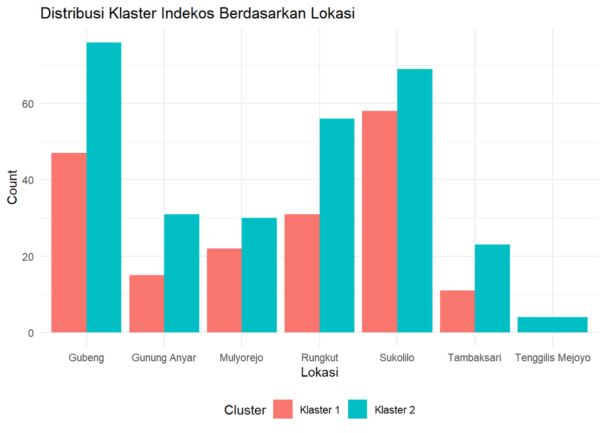

```r
# Visualisasi Lokasi terhadap cluster
ggplot(df, aes(x = Lokasi, fill = cluster)) +
  geom_bar(position = "dodge") +
  labs(title = "Distribusi Klaster Indekos Berdasarkan Lokasi", x = "Lokasi", y = "Count", fill = "Cluster") +
  theme_minimal() +
  theme(legend.position = "bottom")
```

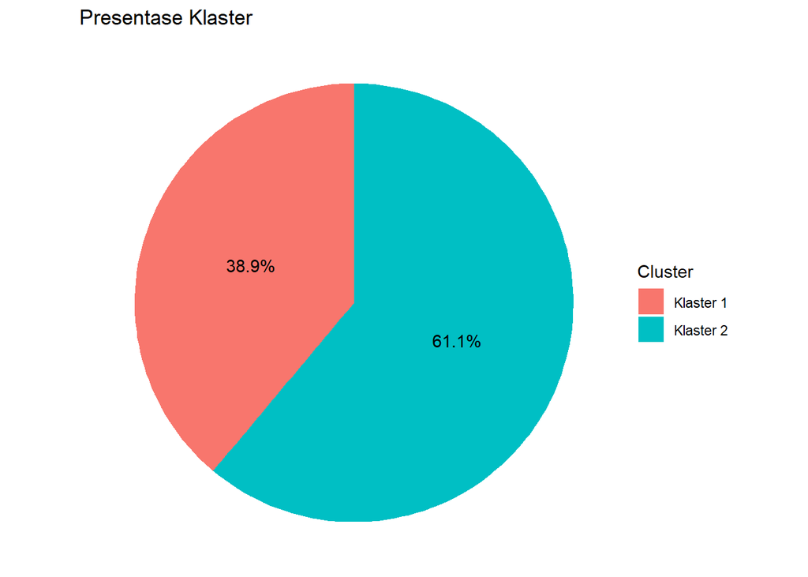

```r
# Hitung frekuensi setiap klaster
cluster_counts <- table(df$cluster)

# Konversi ke dataframe
cluster_df <- as.data.frame(cluster_counts)
colnames(cluster_df) <- c("Cluster", "Count")

# Tambahkan kolom untuk persentase
cluster_df$Percentage <- round(cluster_df$Count / sum(cluster_df$Count) * 100, 1)

# Buat pie chart
ggplot(cluster_df, aes(x = "", y = Count, fill = Cluster)) +
  geom_bar(stat = "identity", width = 1) +
  coord_polar(theta = "y") +
  labs(title = "Presentase Klaster", x = "", y = "") +
  theme_void() +
  geom_text(aes(label = paste0(Percentage, "%")), position = position_stack(vjust = 0.5))
```

```r
table(df$cluster)
```

```
#>
#> Klaster 1 Klaster 2
#>       184       289
```

# 5 Save Data

```r
production_df <- c("Link", "Nama", "Maps", "Latitude", "Longitude",
                   "Jenis", "Lokasi", "Harga", "Luas.Kamar", "UPN",
                   "Listrik", "K.Mandi.Dalam", "AC", "WiFi", "Kasur", "Akses.24.Jam", "cluster")

production <- df[, production_df]
```

```r
# Reset index
rownames(production) <- seq(nrow(production))
```

```r
tail(production)
```

|  | Link | Nama | Maps | Latitude | Longitude | Jenis | Lokasi | Harga | Luas.Kamar | UPN | Listrik | K.Mandi.Dalam | AC | WiFi | Kasur | Akses.24.Jam | cluster |
| --- | --- | --- | --- | --- | --- | --- | --- | --- | --- | --- | --- | --- | --- | --- | --- | --- | --- |
| 468 | https://mamikos.com/room/kost-kota-surabaya-kost-putra-eksklusif-kost-32-tipe-single-bed-sukolilo-surabaya-2?redirection_source=list%20kos%20result | Kost 32 Tipe Single Bed Sukolilo Surabaya | https://maps.google.com/maps?z=7&q=-7.2940938428085,112.80368607491 | -7.294094 | 112.8037 | Putra | Sukolilo | 1800000 | 12.0 | 4.611752 | Tidak termasuk listrik | Yes | Yes | Yes | Yes | Yes | Klaster 2 |
| 469 | https://mamikos.com/room/kost-kota-surabaya-kost-putra-eksklusif-kost-griyaku-deluxe-sukolilo-surabaya?redirection_source=list%20kos%20result | Kost Griyaku Deluxe Sukolilo Surabaya | https://maps.google.com/maps?z=7&q=-7.292635,112.806338 | -7.292635 | 112.8063 | Putra | Sukolilo | 1750000 | 7.5 | 4.873151 | Tidak termasuk listrik | Yes | Yes | Yes | Yes | Yes | Klaster 2 |
| 470 | https://mamikos.com/room/kost-surabaya-kost-putra-murah-kost-bu-antono-tmb-7-tipe-a-mulyorejo-surabaya?redirection_source=list%20kos%20result | Kost Bu Antono TMB 7 Tipe A Mulyorejo Surabaya | https://maps.google.com/maps?z=7&q=-7.276612,112.786996 | -7.276612 | 112.7870 | Putra | Mulyorejo | 550000 | 6.0 | 6.248669 | Tidak termasuk listrik | No | No | No | Yes | Yes | Klaster 1 |
| 471 | https://mamikos.com/room/kost-kota-surabaya-kost-putri-eksklusif-kost-griya-putri-bu-lidia-sukolilo-surabaya?redirection_source=list%20kos%20result | Kost Griya Putri Bu Lidia Sukolilo Surabaya | https://maps.google.com/maps?z=7&q=-7.292577,112.808134 | -7.292577 | 112.8081 | Putri | Sukolilo | 2599999 | 12.0 | 4.961695 | Tidak termasuk listrik | Yes | Yes | Yes | Yes | Yes | Klaster 2 |
| 472 | https://mamikos.com/room/kost-kota-surabaya-kost-putra-eksklusif-kost-veka-sukolilo-surabaya-2?redirection_source=list%20kos%20result | Kost Veka Sukolilo Surabaya | https://maps.google.com/maps?z=7&q=-7.2893543,112.80338 | -7.289354 | 112.8034 | Putra | Sukolilo | 1600000 | 9.0 | 5.096042 | Tidak termasuk listrik | Yes | Yes | Yes | Yes | Yes | Klaster 2 |
| 473 | https://mamikos.com/room/kost-kota-surabaya-kost-putra-eksklusif-kost-griya-siswa-mulyorejo-surabaya?redirection_source=list%20kos%20result | Kost Griya Siswa Mulyorejo Surabaya | https://maps.google.com/maps?z=7&q=-7.2893543,112.80338 | -7.289354 | 112.8034 | Putra | Mulyorejo | 1400000 | 12.0 | 5.096042 | Tidak termasuk listrik | Yes | Yes | Yes | Yes | Yes | Klaster 2 |

# 6 Prediksi Cluster Data Baru

```r
# Load libraries
library(cluster)
library(dplyr)

# Scaling parameters (pastikan production adalah data pelatihan)
scaling_params <- list(center = c(Harga = mean(df$Harga), Luas.Kamar = mean(df$Luas.Kamar), UPN = mean(df$UPN)),
                       scale = c(Harga = sd(df$Harga), Luas.Kamar = sd(df$Luas.Kamar), UPN = sd(df$UPN)))

# Scale function
scale_data <- function(data, scaling_params) {
  data <- data %>%
    mutate(Harga.Scale = (Harga - scaling_params$center["Harga"]) / scaling_params$scale["Harga"],
           Luas.Kamar.Scale = (Luas.Kamar - scaling_params$center["Luas.Kamar"]) /  scaling_params$scale["Luas.Kamar"],
           UPN.Scale = (UPN - scaling_params$center["UPN"]) / scaling_params$scale["UPN"],
           Jenis = as.factor(Jenis),
           Listrik = as.factor(Listrik),
           K.Mandi.Dalam = as.factor(K.Mandi.Dalam),
           AC = as.factor(AC))
  return(data)
}

# Data baru
new_data <- data.frame(Harga = 1500000,
                       Luas.Kamar = 20,
                       UPN = 1.2,
                       Jenis = "Campur",
                       Listrik = "Termasuk listrik",
                       K.Mandi.Dalam = "Yes",
                       AC = "No")

# Scale the new data using the provided scaling parameters
new_data_scaled <- scale_data(new_data, scaling_params)

# Gabungkan data pelatihan dengan data baru
df_combined <- bind_rows(df, new_data_scaled)

# Kolom yang digunakan dalam model
selected_col <- c("Harga.Scale", "Luas.Kamar.Scale", "UPN.Scale", "Jenis", "Listrik", "K.Mandi.Dalam", "AC")

# Gower distance untuk data baru
df_gower_combined <- daisy(df_combined[, selected_col], metric = "gower")

# Convert Gower distance object to matrix
df_gower_combined_matrix <- as.matrix(df_gower_combined)

# Jarak antara data baru dan data pelatihan
gower_distance_new <- df_gower_combined_matrix[nrow(df_combined), 1:nrow(df)]

# Menentukan klaster data baru
cluster_new_data <- pam_fit2$clustering[which.min(gower_distance_new)]

# Filter data pelatihan yang berada dalam klaster yang sama dengan data baru
same_cluster_indices <- which(pam_fit2$clustering == cluster_new_data)
gower_distance_same_cluster <- gower_distance_new[same_cluster_indices]

# Menampilkan 20 kos terdekat dalam klaster yang sama
nearest_kos_indices <- same_cluster_indices[order(gower_distance_same_cluster)[1:20]]
nearest_kos <- df[nearest_kos_indices, ]

# Membuat dataframe hasil dengan jarak Gower
results <- nearest_kos %>%
  mutate(Gower_Distance = gower_distance_same_cluster[order(gower_distance_same_cluster)[1:20]]) %>%
  select(Harga, Luas.Kamar, UPN, Jenis, Listrik, K.Mandi.Dalam, AC, cluster, Gower_Distance)

# Hasil klasterisasi
print(paste("Klaster data baru:", cluster_new_data))
```

```
#> [1] "Klaster data baru: 1"
```

```r
print("20 kos terdekat dalam klaster yang sama beserta jarak Gower:")
```

```
#> [1] "20 kos terdekat dalam klaster yang sama beserta jarak Gower:"
```

```r
print(results)
```

```
#>       Harga Luas.Kamar       UPN  Jenis          Listrik K.Mandi.Dalam AC
#> 435 1000000      12.00 7.4691883 Campur Termasuk listrik           Yes No
#> 405 1000000      12.00 8.3913941 Campur Termasuk listrik           Yes No
#> 47  1350000       9.90 0.8451556 Campur Termasuk listrik            No No
#> 78  1050000      12.00 0.9720614  Putri Termasuk listrik           Yes No
#> 57  1100000       9.00 0.7015967  Putri Termasuk listrik           Yes No
#> 101  750000      12.25 1.5071407  Putri Termasuk listrik           Yes No
#> 35   900000       9.00 0.7561127  Putri Termasuk listrik           Yes No
#> 99   500000       9.00 1.2380403 Campur Termasuk listrik            No No
#> 31   800000       9.00 2.4584747  Putra Termasuk listrik           Yes No
#> 48   500000       9.00 1.0531210  Putra Termasuk listrik           Yes No
#> 392  600000      12.00 3.7763175 Campur Termasuk listrik            No No
#> 231  900000      13.50 5.6345739  Putra Termasuk listrik           Yes No
#> 166 1000000      15.00 7.2950571  Putri Termasuk listrik           Yes No
#> 286  650000       9.00 3.8455750  Putri Termasuk listrik           Yes No
```

[output cut: 27 more lines]

# 7 Export Data to RDS

```r
# Simpan data dan model ke dalam file RDS
saveRDS(production, "production.rds")
saveRDS(pam_fit2, "pam_fit2.rds")
```